# M3: Trajectory Creation & Visualization

Day 1 — Introduction to Movement Ecology

Animal Movement Analyses for Ecologists | SYSU Shenzhen

## Learning Objectives

By the end of this module you will be able to:

1. Build a multi-individual `amt` track (`track_xyt`) from cleaned `move2` data, and set/reproject its coordinate reference system
2. Construct per-individual trajectories as `sf` `LINESTRING` objects and map them interactively, optionally overlaying a contextual shapefile
3. Animate multiple individuals’ movement through time with `gganimate` and `moveVis`, and recognize when each tool — and an animation at all — is the right choice

**Packages used:** `amt`, `sf`, `move2`, `tidyverse`, `lubridate`, `units`, `mapview`, `gganimate`, `moveVis`

## Ecological context

A cleaned table of GPS fixes is still just a list of points. Connecting those points into trajectories — ordered, individual-specific paths through space and time — is what lets us see animal movement paths. For the Athi-Kaputiei wildebeest, navigating a landscape of fences, roads, and expanding settlement at Nairobi’s edge, trajectory visualization can tell us whether an animal’s path tracks *along* a barrier or threads *through* a gap has direct implications for connectivity and where conservation interventions should focus. A clear interactive map, or a short animation of a herd moving across a season, often does more to engage land-use planners, park managers, or pastoralist communities than a table of movement statistics ever will.

In this module we will turn cleaned point data into trajectories and into animations with `gganimate` and `moveVis`. We’ll set up the `amt` track we need for this, too — but the quantitative movement metrics it produces (step length, turning angle, speed) are the topic of the next module.

## 1. Setup

### 1.1 Load packages

```r
# install.packages(c("amt", "sf", "move2", "tidyverse", "lubridate", "gt", "mapview", "gganimate"))

library(amt)         # Tracks, resampling, step metrics
library(sf)          # Spatial vector data — points and lines
library(move2)       # move2 helpers (mt_track_id, etc.)
library(tidyverse)   # Data wrangling and visualization
library(lubridate)   # Timestamps and durations
library(mapview)     # Quick interactive maps
```

### 1.2 Load the cleaned data from Module 2

```r
load("Data/WB_clean.rdata")   # loads WB.mv2, saved at the end of Module 2

cat("Starting point:", n_distinct(mt_track_id(WB.mv2)), "animals,", nrow(WB.mv2), "fixes\n")
```

```
## Starting point: 12 animals, 99377 fixes
```

### 1.3 Define coordinate reference systems

These were defined in Modules 1–2 but aren’t stored in the `.rdata` file, so we redefine them here.

```r
latlong_crs <- "EPSG:4326"   # WGS84 geographic — what move2/Movebank gives us
utm_crs     <- "EPSG:32737"  # UTM Zone 37S — metric, appropriate for Athi-Kaputiei, Kenya
```

## 2. Building a multi-individual `amt` track

`amt` is built around the `track_xy`/`track_xyt` classes — lightweight tibbles with standardized `x_`, `y_`, `t_` columns plus an `id` column when there’s more than one individual. We need to hand it plain dataframe, not a `move2`/`sf` object, so the first step is extracting coordinates out of `WB.mv2`’s point geometry.

### 2.1 From `move2` geometry to plain x/y/t/id columns

```r
WB_df <- WB.mv2 %>%
  mutate(x = sf::st_coordinates(.)[, 1],
         y = sf::st_coordinates(.)[, 2]) %>%
  as_tibble() %>%
  transmute(id = individual_local_identifier,
            x, y,
            t = timestamp) %>%
  arrange(id, t)

head(WB_df)
```

```
## # A tibble: 6 × 4
##   id          x     y t
##   <fct>   <dbl> <dbl> <dttm>
## 1 Karbolo  37.0 -1.73 2010-10-19 00:00:00
## 2 Karbolo  37.0 -1.73 2010-10-19 03:00:00
## 3 Karbolo  37.0 -1.73 2010-10-19 04:00:00
## 4 Karbolo  37.0 -1.73 2010-10-19 05:00:00
## 5 Karbolo  37.0 -1.73 2010-10-19 06:00:00
## 6 Karbolo  37.0 -1.73 2010-10-19 07:00:00
```

### 2.2 `make_track()`

```r
trk_all <- make_track(WB_df, x, y, t, id = id, crs = latlong_crs)

class(trk_all)     # track_xyt, track_xy, tbl_df, tbl, data.frame
```

```
## [1] "track_xyt"  "track_xy"   "tbl_df"     "tbl"        "data.frame"
```

```r
head(trk_all)
```

```
## # A tibble: 6 × 4
##      x_    y_ t_                  id
## * <dbl> <dbl> <dttm>              <fct>
## 1  36.8 -1.36 2010-10-15 13:00:00 Sotua
## 2  36.8 -1.36 2010-10-15 14:00:00 Sotua
## 3  36.8 -1.36 2010-10-15 15:00:00 Sotua
## 4  36.8 -1.36 2010-10-15 18:00:00 Sotua
## 5  36.9 -1.42 2010-10-15 18:01:00 Laingoni
## 6  36.9 -1.42 2010-10-15 21:00:00 Laingoni
```

> **Note:** `trk_all` holds *all* individuals in one tibble. Several `amt` functions used later for movement-metric analysis (e.g., `summarize_sampling_rate()`, `track_resample()`) operate on a single individual track at a time and need to be applied per individual via `nest()`/`map()`/`unnest()` — the same pattern used throughout `amt`’s own documentation for multi-animal data.

### 2.3 Reproject to a metric CRS

```r
trk_all <- transform_coords(trk_all, utm_crs)

head(trk_all)
```

```
## # A tibble: 6 × 4
##        x_       y_ t_                  id
## *   <dbl>    <dbl> <dttm>              <fct>
## 1 260296. 9849694. 2010-10-15 13:00:00 Sotua
## 2 260329. 9849518. 2010-10-15 14:00:00 Sotua
## 3 260393. 9849505. 2010-10-15 15:00:00 Sotua
## 4 260432. 9849416. 2010-10-15 18:00:00 Sotua
## 5 270898. 9843177. 2010-10-15 18:01:00 Laingoni
## 6 270899. 9843183. 2010-10-15 21:00:00 Laingoni
```

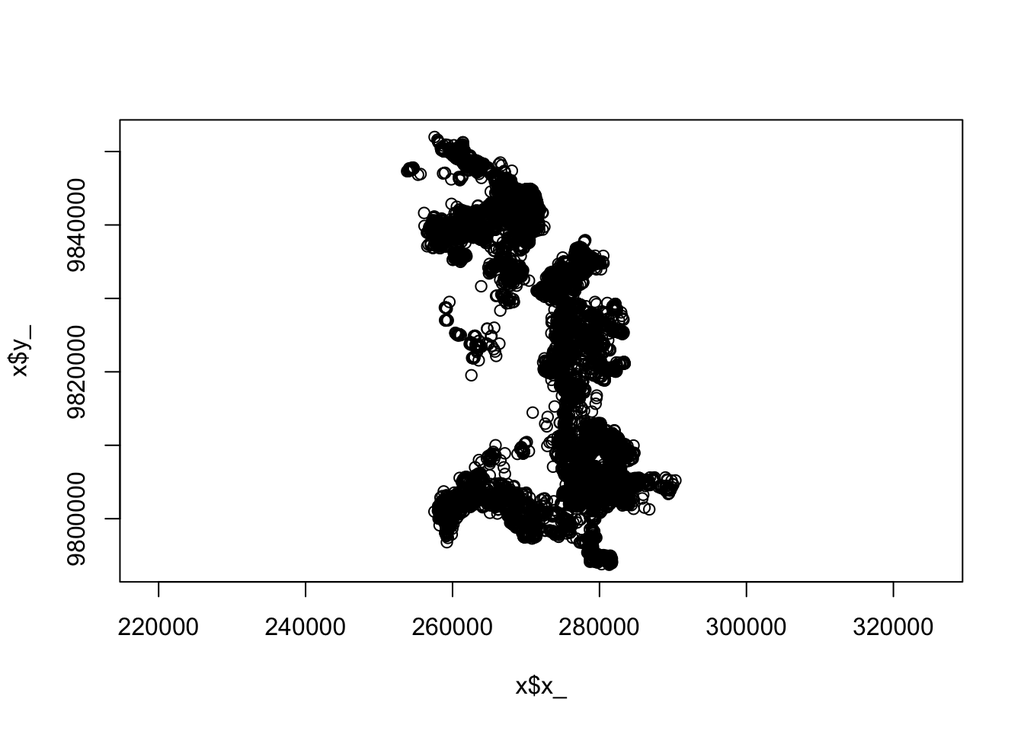

```r
plot(trk_all)
```

You can see that the values of x_ and y_ have been updated, due to the reprojection to UTM.

> **Looking ahead:** `trk_all` is now a ready-to-use, projected `amt` track for all individuals. However, it is still by nature a point dataframe (hence the base `plot` function still generates points). In the next module, we’ll pick it back up to check each animal’s empirical sampling rate, resample to regular bursts, and compute step length / turning angle as movement metrics. For now, we focus on visualizing the raw trajectories themselves.

## 3. Trajectories as spatial lines (`sf`)

`amt` steps are great for movement *metrics*, but for mapping a trajectory as a continuous path, plain `sf` `LINESTRING`s are simpler and more directly compatible with other spatial layers (boundaries, land cover, etc.).

### 3.1 Points → projected `sf` → `LINESTRING`

```r
WB.sf <- sf::st_as_sf(as.data.frame(WB.mv2)) %>%
  sf::st_transform(utm_crs)

WB.lines <- WB.sf %>%
  group_by(individual_local_identifier) %>%
  dplyr::summarise(do_union = FALSE) %>%
  sf::st_cast("LINESTRING")

WB.lines
```

```
## Simple feature collection with 12 features and 1 field
## Geometry type: LINESTRING
## Dimension:     XY
## Bounding box:  xmin: 253818 ymin: 9793728 xmax: 290328.6 ymax: 9851979
## Projected CRS: WGS 84 / UTM zone 37S
## # A tibble: 12 × 2
##    individual_local_identifier                                          geometry
##    <fct>                                                        <LINESTRING [m]>
##  1 Karbolo                     (281442.1 9808391, 281892.7 9808932, 282340.4 98…
##  2 Kikaya                      (264449.6 9803069, 264748.5 9802814, 264573.8 98…
##  3 Kiranto                     (274313.8 9820551, 274302.9 9820626, 274307.7 98…
##  4 Laingoni                    (270897.6 9843177, 270898.6 9843183, 270935.8 98…
##  5 Ne Mpaash                   (267590.4 9842388, 267590.8 9842389, 267578.2 98…
##  6 Noontare                    (267596.7 9842770, 267602.1 9842772, 267600.1 98…
##  7 Ntishya                     (278017.1 9806180, 276941.4 9803741, 277733.1 98…
##  8 Ole Nagol                   (268087.3 9842542, 268176.3 9842534, 268599.5 98…
##  9 Paita                       (282927.3 9803782, 282316.6 9804514, 282336.3 98…
## 10 Peria                       (277960 9806360, 277953.8 9806365, 277960.7 9806…
## 11 Sawani                      (265769.2 9801579, 265444.9 9802102, 265257.3 98…
## 12 Sotua                       (260295.7 9849694, 260328.9 9849518, 260392.7 98…
```

> **Note:** `group_by(individual_local_identifier) %>% summarise(do_union = FALSE)` collapses each animal’s points, *in row order*, into one connected line; `st_cast("LINESTRING")` then sets the geometry type. `do_union = FALSE` matters — `st_union()`’s default behavior can reorder points, which would scramble the trajectory into a meaningless path. This is also why we re-sorted by `id` + `timestamp` back in Module 2.

### 3.2 Interactive trajectory map

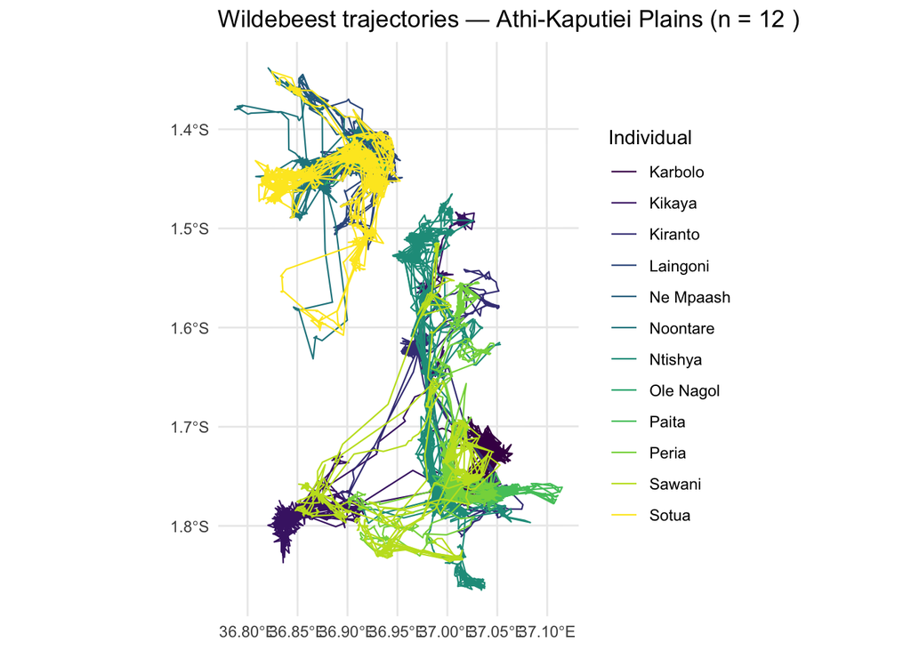

```r
ggplot() +
  geom_sf(data = WB.lines, aes(color = individual_local_identifier), linewidth = 0.4) +
  scale_color_viridis_d(name = "Individual") +
  labs(title = paste("Wildebeest trajectories — Athi-Kaputiei Plains (n =",
                      n_distinct(WB.lines$individual_local_identifier), ")")) +
  theme_minimal()
```

```r
mapview(WB.lines, zcol = "individual_local_identifier", layer.name = "Trajectories", lwd = 2) +
  mapview(WB.sf %>% slice_sample(n = 2000), zcol = "individual_local_identifier",
          layer.name = "Fixes", cex = 1.5, alpha = 0.6)
```

[interactive chart not shown]

### 3.3 (Optional) Overlay a shapefile

Any polygon shapefile — a protected-area boundary, a fence network, a land-cover layer — can be laid under or over your trajectories the same way. We use a protected-area boundary purely as one example; this repository doesn’t ship that particular shapefile, but if you have one for your own study system, the same pattern applies directly:

```r
# Read in your boundary (reproject to match your trajectories' CRS):
# boundary <- sf::st_read("Data/your_boundary.shp", quiet = TRUE) %>%
#   sf::st_transform(utm_crs)
#
# mapview(WB.lines, zcol = "individual_local_identifier", layer.name = "Trajectories") +
#   mapview(boundary, col.regions = "green", alpha.regions = 0.3, layer.name = "Reserve boundary")
```

## 4. Animating movement through time (`gganimate` & `moveVis`)

### 4.1 Why animate?

An animation makes spatial *and* temporal pattern visible at once in a way a static map cannot — a herd moving together, an individual peeling off, a synchronized response to rainfall. It’s a communication tool as it’s often the fastest way to get a non-specialist audience to see the same pattern those metrics describe.

We’ll build the same demo two ways, because the two tools trade off differently:

- **`gganimate`** (Pedersen & Robinson) animates any `ggplot2` plot through time. General-purpose, no spatial-data dependencies, no internet connection needed — good for a fast first look.
- **`moveVis`** (Schwalb-Willmann et al. 2020, *Methods in Ecology and Evolution* 11:664–669, doi:10.1111/2041-210X.13374) is purpose-built for animating `move2` tracks and can overlay a real basemap (OpenStreetMap tiles by default) underneath the moving points — closer to a presentation- or publication-ready figure, at the cost of an internet connection and slower rendering. For a system where fences, roads, and the edge of Nairobi’s built-up area shape where animals can move, that landscape context is often worth it.

**A caveat on `moveVis`, and how we work around it:** its `align_move()` step — which puts every individual on the same time grid before animating, a required input to `frames_spatial()` — has a couple of bugs that show up on data like ours. You don’t need to know the details to use this module: we’ve rewritten a corrected version of the function so it works correctly on this dataset, and Section 4.5 below shows you how to load and use it in place of the original.

Rather than drop the package over two fixable bugs, Section 4.5 sources this **locally patched drop-in replacement for `align_move()`** — identical to the released version except for the fixes — and feeds its corrected output into the real, unmodified `frames_spatial()` + `animate_frames()`.

### 4.2 Subsetting for a tractable demo

```r
# install.packages(c("gganimate", "gifski", "moveVis", "units"))
library(gganimate)   # animate ggplot2 plots through time

# For a *quick*, in-class demo we restrict to a few individuals and a short
# time window: animating the full population over the full deployment means
# thousands of frames, which is impractical to render live.
demo_ids   <- unique(as.character(WB.mv2$individual_local_identifier))[1:3]
demo_start <- min(WB.mv2$timestamp)
demo_end   <- demo_start + weeks(2)

WB_demo <- WB.mv2 %>%
  filter(as.character(individual_local_identifier) %in% demo_ids,
         timestamp >= demo_start, timestamp <= demo_end)

WB_demo_df <- WB_demo %>%
  mutate(x = sf::st_coordinates(.)[, 1],
         y = sf::st_coordinates(.)[, 2]) %>%
  as_tibble() %>%
  transmute(id = as.character(individual_local_identifier), x, y, t = timestamp) %>%
  arrange(id, t)

cat(n_distinct(WB_demo_df$id), "animals,", nrow(WB_demo_df), "fixes in the demo window\n")
```

```
## 3 animals, 509 fixes in the demo window
```

`WB_demo` (still a `move2` object) feeds the `moveVis` path below; `WB_demo_df` (a plain tibble) feeds `gganimate`.

### 4.3 `gganimate`: build and preview

> **Heads up:** rendering even ~100 frames takes a bit of time. This chunk is marked `eval=FALSE` so the module knits quickly — run it interactively in your own session.

```r
anim <- ggplot(WB_demo_df, aes(x = x, y = y, color = id)) +
  geom_point(size = 3) +
  scale_color_viridis_d(name = "Individual") +
  coord_quickmap() +
  labs(title = "Wildebeest movement — {format(frame_time, '%Y-%m-%d %H:%M')}",
       x = "Longitude", y = "Latitude") +
  theme_minimal() +
  transition_time(t) + # maps `t` onto animation frames and linearly interpolates each individual's position between consecutive real fixes. Effective for visualization but not robust enough for analyses
  shadow_wake(wake_length = 0.2, size = TRUE) # leaves each point a short fading trail so direction of travel is easy to read.

animate(anim, nframes = 100, fps = 10, width = 800, height = 600,
        renderer = gifski_renderer())   # preview
```

### 4.4 `gganimate`: save the animation

```r
anim_gif <- animate(anim, nframes = 200, fps = 12, width = 900, height = 700,
                     renderer = gifski_renderer())
anim_save("wildebeest_movement.gif", anim_gif)
```

Next: the same demo window, animated with `moveVis` and a real basemap underneath.

### 4.5 A locally patched `align_move()`

`align_move()` is the step that puts every individual on the same time grid before animating — a required input to `frames_spatial()`. `align_move_fixed.R` is a drop-in replacement for it: same inputs, same output, with the bugs from 4.1 fixed. You don’t need to read the script to use it — `source()` it once, then call `align_move_fixed()` exactly like you would `align_move()`.

```r
# install.packages(c("moveVis", "units"))
library(moveVis)
library(units)

source("./align_move_fixed.R")
```

> Curious what the patch actually does? Open `align_move_fixed.R` — each fix is commented at the point it applies. If you scale this up to the full dataset, rerun the sanity check in 4.6 first to confirm the fix still holds.

### 4.6 `moveVis`: build frames and animate

```r
WB_aligned <- align_move_fixed(WB_demo, res = units::set_units(6, "hours"))

# sanity check: the original bug collapsed every individual's interpolated
# positions onto a single point. Confirm each individual still has many
# distinct coordinates after alignment (should be close to its row count,
# not 1):
sapply(split(WB_aligned, mt_track_id(WB_aligned)),
       function(x) length(unique(sf::st_coordinates(x)[, 1])))
```

```r
frames <- frames_spatial(WB_aligned, map_service = "osm", map_type = "topographic",
                          path_legend = TRUE, path_legend_title = "Individual") %>%
  add_northarrow(position = "bottomleft") %>%
  add_scalebar(colour = "black", position = "bottomright") %>%
  add_timestamps(type = "label") %>%
  add_progress()

frames[[1]]   # preview a single frame before rendering the full animation
```

```r
animate_frames(frames, out_file = "wildebeest_movement_movevis.gif", overwrite = TRUE)
```

`frames_spatial()` pulls OpenStreetMap tiles for the extent of `WB_aligned` and draws each individual’s path with a fading tail; `add_*()` functions layer on a north arrow, scale bar, timestamp label, and progress bar before `animate_frames()` renders the GIF. Compare the result to the `gganimate` version above — same demo window, same individuals, but now with the fence lines, roads, and settlement edge from Section 1’s ecological framing visible underneath the movement.

## Practice: Apply to your own data

Now build and visualize trajectories for your own dataset.

1. **Build an `amt` track** with `make_track()`. Double check `has_crs()` returns `TRUE` before going further — a missing CRS will silently break `transform_coords()` and any distance-based metric computed from it later.
2. **Build `LINESTRING` trajectories** for 2–3 individuals and map them. Do the paths match what you’d expect given your species’ ecology and your study area’s landscape features?
3. **If you have a relevant shapefile** (a boundary, fence line, land-cover layer), overlay it on your trajectory map as in Section 3.3.
4. **(Stretch) Animate a short window** with `gganimate` and/or `moveVis` for a few individuals. What does the animation reveal that the static trajectory map doesn’t, and what does the `moveVis` basemap add over the `gganimate` version?

## Key functions reference

| Function | Package | Purpose |
| --- | --- | --- |
| `make_track()` | `amt` | Build a `track_xy`/`track_xyt` object from x/y(/t) columns |
| `has_crs()` | `amt` | Check whether a track’s CRS is set |
| `transform_coords()` | `amt` | Reproject a track (wraps `sf::st_transform()`) |
| `st_cast()` | `sf` | Convert geometry type (e.g., `POINT` → `LINESTRING`) |
| `st_transform()` | `sf` | Reproject spatial data to a new CRS |
| `mapview()` | `mapview` | Quick interactive map |
| `coord_quickmap()` | `ggplot2` | Quick approximate aspect-ratio correction for lon/lat data |
| `transition_time()` | `gganimate` | Map a time column onto animation frames, interpolating between fixes |
| `shadow_wake()` | `gganimate` | Leave a fading trail behind each animated point |
| `animate()` | `gganimate` | Render a `gganimate` object to GIF/video |
| `align_move()` | `moveVis` | Align individuals to a uniform time grid for animation (patched locally — sourced from `align_move_fixed.R`, see 4.5) |
| `frames_spatial()` | `moveVis` | Build per-frame plots with a basemap underneath each individual’s path |
| `add_northarrow()`, `add_scalebar()`, `add_timestamps()`, `add_progress()` | `moveVis` | Layer map annotations onto `frames_spatial()` output |
| `animate_frames()` | `moveVis` | Render a `moveVis` frames object to GIF/video |

*Next: **Day 2 — Movement Metrics** — having built and visualized individual trajectories, we pick `trk_all` back up to check each animal’s sampling rate, resample to regular bursts, and quantify movement itself: speed, turning angles, and net displacement, as a foundation for behavioral segmentation.*